# Lab #2 Data visualization

# Calculate a correlation matrix between the time points (use Pearson’s correlation)

Use the argument `use=pairwise.complete.obs` since all of these arrays have at least one missing value

```r
# Compute correlation matrix
Pearsons_cor <- cor(cdc15, use="pairwise.complete.obs")
knitr::kable(head(Pearsons_cor), caption="correlation matrix")
```

correlation matrix

|  | cdc15_10 | cdc15_30 | cdc15_50 | cdc15_70 | cdc15_80 | cdc15_90 | cdc15_100 | cdc15_110 | cdc15_120 | cdc15_130 | cdc15_140 | cdc15_150 | cdc15_160 | cdc15_170 | cdc15_180 | cdc15_190 | cdc15_200 | cdc15_210 | cdc15_220 | cdc15_230 | cdc15_240 | cdc15_250 | cdc15_270 | cdc15_290 |
| --- | --- | --- | --- | --- | --- | --- | --- | --- | --- | --- | --- | --- | --- | --- | --- | --- | --- | --- | --- | --- | --- | --- | --- | --- |
| cdc15_10 | 1.0000000 | 0.6596192 | 0.3803137 | 0.0404035 | -0.2751942 | 0.0523843 | -0.1767124 | 0.1467408 | -0.1876123 | 0.1877307 | -0.2074429 | -0.0831420 | -0.4011089 | -0.1423566 | -0.3803879 | 0.0876782 | -0.2675389 | 0.0218682 | -0.3133891 | -0.0785130 | -0.3632531 | 0.0903136 | -0.0725296 | -0.0619448 |
| cdc15_30 | 0.6596192 | 1.0000000 | 0.6514299 | -0.0123520 | -0.2871251 | -0.1523217 | -0.2277262 | -0.1263425 | -0.2345103 | 0.2064697 | 0.0860346 | 0.1629768 | -0.1508526 | 0.0159877 | -0.2509981 | -0.1356663 | -0.3285285 | -0.2747687 | -0.3590467 | -0.0508677 | -0.2550204 | 0.0046905 | -0.0817655 | -0.1385329 |
| cdc15_50 | 0.3803137 | 0.6514299 | 1.0000000 | 0.3074888 | -0.0814436 | 0.0461123 | -0.2661158 | -0.2012584 | -0.4181861 | 0.0334770 | -0.0791583 | 0.2113644 | -0.0760536 | 0.2409681 | -0.1856587 | 0.0713270 | -0.2997538 | -0.1955526 | -0.4877753 | -0.2323132 | -0.4371303 | -0.0005286 | -0.0571931 | -0.0049578 |
| cdc15_70 | 0.0404035 | -0.0123520 | 0.3074888 | 1.0000000 | 0.1384818 | 0.4978753 | -0.0867244 | 0.2037753 | -0.3205380 | -0.0097639 | -0.3075485 | -0.0108741 | -0.1833695 | 0.2435317 | -0.1404235 | 0.3518633 | -0.1388058 | 0.2293663 | -0.3505140 | -0.3939611 | -0.4728643 | -0.1201930 | -0.1435355 | -0.0828570 |
| cdc15_80 | -0.2751942 | -0.2871251 | -0.0814436 | 0.1384818 | 1.0000000 | 0.0078318 | 0.4445420 | -0.1403235 | 0.3539467 | -0.4701251 | 0.0851332 | -0.1584651 | 0.3519724 | -0.0940005 | 0.3172761 | -0.1923526 | 0.3621699 | -0.2257829 | 0.3807039 | -0.0739112 | 0.1334928 | -0.5967891 | -0.5104496 | -0.4782053 |
| cdc15_90 | 0.0523843 | -0.1523217 | 0.0461123 | 0.4978753 | 0.0078318 | 1.0000000 | -0.0046598 | 0.5843085 | -0.2031707 | 0.1811676 | -0.4913561 | -0.1622752 | -0.4200485 | -0.0507410 | -0.3406161 | 0.5073628 | -0.1449039 | 0.4701430 | -0.3281936 | -0.3927801 | -0.5111513 | 0.0861390 | -0.0850771 | 0.0722216 |

### Plot the correlation matrix

Title the plot, label the axes, and provide a legend of the color gradient

```r
# Load the packages
library(gplots)
```

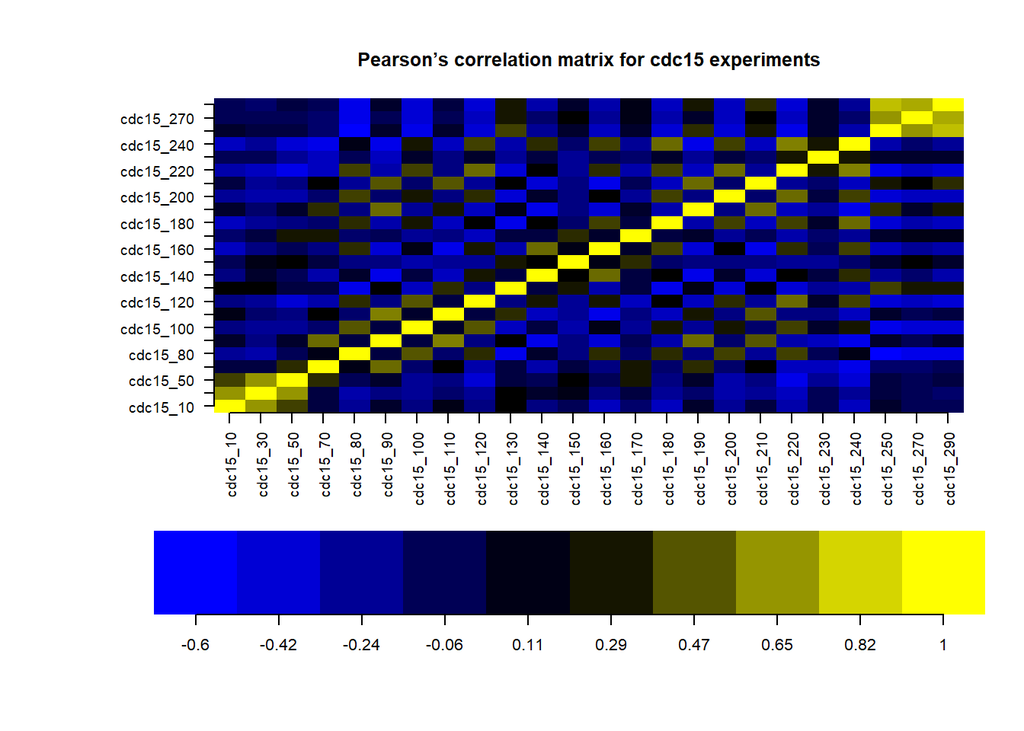

```r
# Plot
layout(matrix(c(1,1,1,1,1,1,1,1,2,2), 5, 2, byrow = TRUE))
par(oma=c(5,7,1,1))
cx <- rev(colorpanel(25,"yellow","black","blue"))
leg <- seq(min(Pearsons_cor, na.rm=T), max(Pearsons_cor, na.rm=T), length=10)
# title the plot,
image(Pearsons_cor,
    main="Pearson’s correlation matrix for cdc15 experiments", axes=F, col=cx)
# label the axes
axis(1, at=seq(0,1,length=ncol(Pearsons_cor)),
    label=dimnames(Pearsons_cor)[[2]], cex.axis=0.9, las=2)
axis(2, at=seq(0,1,length=ncol(Pearsons_cor)),
    label=dimnames(Pearsons_cor)[[2]], cex.axis=0.9, las=2)
# provide a legend of the color gradient
# To fix the error: figure margins too large, expand the plot panel
par(mar=c(1,1,1,1))
image(as.matrix(leg), col=cx, axes=F)
tmp <- round(leg,2)
axis(1, at=seq(0,1, length=length(leg)), labels=tmp, cex.axis=1)
```

# Select the gene YAL002W

YAL002W, which is VPS8, a membrane-binding component of the CORVET complex; involved in endosomal vesicle tethering and fusion in the endosome to vacuole protein targeting pathway

Then impute the missing values with the row mean Make sure to cast the gene to numeric

```r
# Impute the missing values with the row mean
VPS8 <- cdc15["YAL002W", ]
mean(as.numeric(VPS8), na.rm=TRUE)
```

```
## [1] 3.857953e-18
```

```r
VPS8[is.na(VPS8)] <- mean(as.numeric(VPS8), na.rm=TRUE)
VPS8
```

```
##             cdc15_10     cdc15_30     cdc15_50 cdc15_70 cdc15_80 cdc15_90
## YAL002W 3.857953e-18 3.857953e-18 3.857953e-18    -0.58     0.23    -0.23
##         cdc15_100 cdc15_110 cdc15_120 cdc15_130 cdc15_140 cdc15_150 cdc15_160
## YAL002W      0.08     -0.62      0.55     -0.32      0.03     -0.56      0.47
##         cdc15_170 cdc15_180    cdc15_190 cdc15_200 cdc15_210 cdc15_220
## YAL002W     -0.15      0.49 3.857953e-18      0.23     -0.49      0.33
##         cdc15_230 cdc15_240 cdc15_250    cdc15_270    cdc15_290
## YAL002W      0.18      0.65     -0.29 3.857953e-18 3.857953e-18
```

```r
# cast the gene to numeric
y <- as.numeric(VPS8)
```

### Generate a profile plot of the gene YAL002W

Title the plot, label the axes, and on the x-axis, provide the time points only for each array (no “cdc15_” prefix) so we can visualize the transcript pattern over time

Use `lwd=line width` in the plot command

```r
# Generate a profile plot
# provide the time points only for each array (no “cdc15_” prefix)
colnames(VPS8)
```

```
##  [1] "cdc15_10"  "cdc15_30"  "cdc15_50"  "cdc15_70"  "cdc15_80"  "cdc15_90"
##  [7] "cdc15_100" "cdc15_110" "cdc15_120" "cdc15_130" "cdc15_140" "cdc15_150"
## [13] "cdc15_160" "cdc15_170" "cdc15_180" "cdc15_190" "cdc15_200" "cdc15_210"
## [19] "cdc15_220" "cdc15_230" "cdc15_240" "cdc15_250" "cdc15_270" "cdc15_290"
```

```r
x <- c(seq(10, 70, by=20), seq(80, 240, by=10), seq(250, 290, by=20))
x
```

```
##  [1]  10  30  50  70  80  90 100 110 120 130 140 150 160 170 180 190 200 210 220
## [20] 230 240 250 270 290
```

```r
# Make sure x and y have the same length
length(x)
```

```
## [1] 24
```

```r
length(y)
```

```
## [1] 24
```

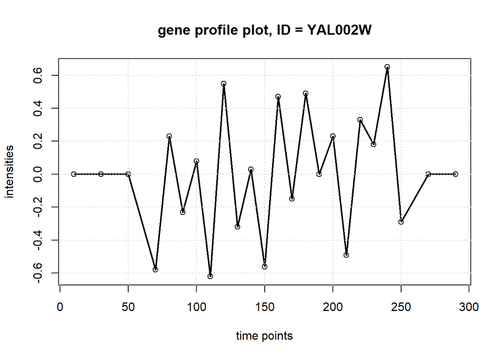

```
## integer(0)
```

```r
# Title the plot, label the axes
plot(x, y,
    xlab="time points", ylab="intensities",
    main="gene profile plot, ID = YAL002W") +
# Use lwd in the plot command (lwd=line width)
lines(x, y, lwd=2) + grid()
```

# Use R shiny to create a simple interactive app

Let’s create a simple shiny app which allows the user to select and correlate any time point verse another time point across all genes

To do this, we can create a server and ui function within the same file, paste both into the R session, then call them with:

`>shinyApp(ui = ui, server = server)`

R shiny app cannot be open in static R Markdown. Use RStudio to run the app.

```r
# Shiny app for cdc15 data
library(shiny)
# ui.R
ui <- shinyUI(pageWithSidebar(
    headerPanel('cdc15 time course experiment'),
    sidebarPanel(
        selectInput('xcol', 'X Variable', names(cdc15)),
        selectInput('ycol', 'Y Variable', names(cdc15),
        selected=names(cdc15)[[2]]),
        # customize point color and symbol
        selectInput('varColor', 'Point color (only for symbol 21)', c("red","green","blue","black")),
        numericInput('pch', 'Plotting symbols', 21, min=1, max=21)
        ),
    mainPanel( plotOutput('plot1') )
))

# server.R
server <- shinyServer(function(input, output, session) {
    # Combine the selected variables into a new data frame
    selectedData <- reactive({ cdc15[, c(input$xcol, input$ycol)] })
    colors <- reactive({input$varColor })
    symbols <- reactive({input$pch })
    output$plot1 <- renderPlot({ par(mar=c(5.1, 4.1, 0, 1))
        plot(selectedData(), col=1, bg=colors(), pch=symbols(), cex=0.5) })
})

shinyApp(ui=ui, server=server)
```

Shiny applications not supported in static R Markdown documents